# Initial Analysis - grand center NDVI

Let’s look at the variables of interest. These are crime index-total, crime index-violent, crime index-property, and green measures.

```r
skimr::skim(df$CRMCYTOTC)
```

```
Skim summary statistics

Variable type: integer
     variable missing complete     n   mean    sd p0 p25 median p75 p100     hist
 df$CRMCYTOTC       0    62086 62086 142.72 96.44  3  70    123 196 1232 ▇▃▁▁▁▁▁▁
```

```r
skimr::skim(df$CRMCYPERC)
```

```
Skim summary statistics

Variable type: integer
     variable missing complete     n  mean     sd p0 p25 median p75 p100     hist
 df$CRMCYPERC       0    62086 62086 183.2 164.23  2  60    134 258 1548 ▇▃▁▁▁▁▁▁
```

```r
skimr::skim(df$CRMCYPROC)
```

```
Skim summary statistics

Variable type: integer
     variable missing complete     n   mean    sd p0 p25 median p75 p100     hist
 df$CRMCYPROC       0    62086 62086 137.11 93.97  3  67    118 188 1318 ▇▃▁▁▁▁▁▁
```

```r
skimr::skim(df$gndctr_ndvi_cbg_adj)
```

```
Skim summary statistics

Variable type: numeric
               variable missing complete     n    mean   sd    p0   p25 median  p75 p100     hist
 df$gndctr_ndvi_cbg_adj       0    62086 62086 1.2e-16 1.52 -3.55 -1.31  0.081 1.24    4 ▁▆▇▆▇▇▃▁
```

First, is there variation in the variables that is attributable to the differences between cities, the level 2 ‘groups’.

```r
t <- df[, c("CRMCYTOTC", "CRMCYPERC", "CRMCYPROC", "gndctr_ndvi_cbg_adj")]
mult.icc(as.data.frame(t), grpid= df$city_st)
```

| Variable | ICC1 | ICC2 |
| --- | --- | --- |
| CRMCYTOTC | 0.3062623 | 0.9891375 |
| CRMCYPERC | 0.3146686 | 0.9895514 |
| CRMCYPROC | 0.3056347 | 0.9891057 |
| gndctr_ndvi_cbg_adj | 0.6809064 | 0.9977332 |

Start with the intercept only models

```r
mod_1a <- lmer(CRMCYTOTC ~ 1 + (1|city_st), data = df)
mod_1b <- lmer(CRMCYPERC ~ 1 + (1|city_st), data = df)
mod_1c <- lmer(CRMCYPROC ~ 1 + (1|city_st), data = df)
summary(mod_1a)
```

```
Linear mixed model fit by REML ['lmerMod']
Formula: CRMCYTOTC ~ 1 + (1 | city_st)
   Data: df

REML criterion at convergence: 721762.7

Scaled residuals:
    Min      1Q  Median      3Q     Max
-3.5537 -0.6298 -0.1036  0.5015 12.9982

Random effects:
 Groups   Name        Variance Std.Dev.
 city_st  (Intercept) 2836     53.25
 Residual             6424     80.15
Number of obs: 62086, groups:  city_st, 301

Fixed effects:
            Estimate Std. Error t value
(Intercept)  136.188      3.103   43.88
```

```r
summary(mod_1b)
```

```
Linear mixed model fit by REML ['lmerMod']
Formula: CRMCYPERC ~ 1 + (1 | city_st)
   Data: df

REML criterion at convergence: 784584.6

Scaled residuals:
    Min      1Q  Median      3Q     Max
-3.3188 -0.6285 -0.1338  0.4863 10.1906

Random effects:
 Groups   Name        Variance Std.Dev.
 city_st  (Intercept)  8112     90.06
 Residual             17667    132.92
Number of obs: 62086, groups:  city_st, 301

Fixed effects:
            Estimate Std. Error t value
(Intercept)  146.107      5.247   27.85
```

```r
summary(mod_1c)
```

```
Linear mixed model fit by REML ['lmerMod']
Formula: CRMCYPROC ~ 1 + (1 | city_st)
   Data: df

REML criterion at convergence: 718218.8

Scaled residuals:
    Min      1Q  Median      3Q     Max
-3.8674 -0.6115 -0.1116  0.4701 14.2897

Random effects:
 Groups   Name        Variance Std.Dev.
 city_st  (Intercept) 2671     51.68
 Residual             6067     77.89
Number of obs: 62086, groups:  city_st, 301

Fixed effects:
            Estimate Std. Error t value
(Intercept)  134.813      3.012   44.76
```

So maybe at this point let’s just look at the ndvi relationship. First as just random intercepts.

```r
mod_2a <- lmer(CRMCYTOTC ~ gndctr_ndvi_cbg_adj + (1|city_st), data = df)
mod_2b <- lmer(CRMCYPERC ~ gndctr_ndvi_cbg_adj + (1|city_st), data = df)
mod_2c <- lmer(CRMCYPROC ~ gndctr_ndvi_cbg_adj + (1|city_st), data = df)
summary(mod_2a)
```

```
Linear mixed model fit by REML ['lmerMod']
Formula: CRMCYTOTC ~ gndctr_ndvi_cbg_adj + (1 | city_st)
   Data: df

REML criterion at convergence: 712096.4

Scaled residuals:
    Min      1Q  Median      3Q     Max
-3.8493 -0.6245 -0.0843  0.5226 14.3596

Random effects:
 Groups   Name        Variance Std.Dev.
 city_st  (Intercept) 6544     80.90
 Residual             5472     73.97
Number of obs: 62086, groups:  city_st, 301

Fixed effects:
                    Estimate Std. Error t value
(Intercept)         144.7223     4.6827   30.91
gndctr_ndvi_cbg_adj -35.8322     0.3483 -102.88

Correlation of Fixed Effects:
            (Intr)
gndctr_nd__ -0.018
```

```r
summary(mod_2b)
```

```
Linear mixed model fit by REML ['lmerMod']
Formula: CRMCYPERC ~ gndctr_ndvi_cbg_adj + (1 | city_st)
   Data: df

REML criterion at convergence: 781248.9

Scaled residuals:
    Min      1Q  Median      3Q     Max
-3.5490 -0.6015 -0.1251  0.4586 10.6539

Random effects:
 Groups   Name        Variance Std.Dev.
 city_st  (Intercept) 11755    108.4
 Residual             16709    129.3
Number of obs: 62086, groups:  city_st, 301

Fixed effects:
                    Estimate Std. Error t value
(Intercept)         154.6042     6.2947   24.56
gndctr_ndvi_cbg_adj -35.6464     0.6068  -58.74

Correlation of Fixed Effects:
            (Intr)
gndctr_nd__ -0.023
```

```r
summary(mod_2c)
```

```
Linear mixed model fit by REML ['lmerMod']
Formula: CRMCYPROC ~ gndctr_ndvi_cbg_adj + (1 | city_st)
   Data: df

REML criterion at convergence: 707941.7

Scaled residuals:
    Min      1Q  Median      3Q     Max
-4.0083 -0.6170 -0.0849  0.5029 15.6320

Random effects:
 Groups   Name        Variance Std.Dev.
 city_st  (Intercept) 6383     79.89
 Residual             5116     71.53
Number of obs: 62086, groups:  city_st, 301

Fixed effects:
                    Estimate Std. Error t value
(Intercept)         143.3634     4.6240    31.0
gndctr_ndvi_cbg_adj -35.8285     0.3368  -106.4

Correlation of Fixed Effects:
            (Intr)
gndctr_nd__ -0.018
```

Do these fit better than the intercept only models?

```r
anova(mod_1a, mod_2a)
```

```
refitting model(s) with ML (instead of REML)
```

```
Data: df
Models:
mod_1a: CRMCYTOTC ~ 1 + (1 | city_st)
mod_2a: CRMCYTOTC ~ gndctr_ndvi_cbg_adj + (1 | city_st)
       Df    AIC    BIC  logLik deviance  Chisq Chi Df Pr(>Chisq)
mod_1a  3 721773 721800 -360883   721767
mod_2a  4 712109 712145 -356051   712101 9665.7      1  < 2.2e-16 ***
---
Signif. codes:  0 ‘***’ 0.001 ‘**’ 0.01 ‘*’ 0.05 ‘.’ 0.1 ‘ ’ 1
```

```r
anova(mod_1b, mod_2b)
```

```
refitting model(s) with ML (instead of REML)
```

```
Data: df
Models:
mod_1b: CRMCYPERC ~ 1 + (1 | city_st)
mod_2b: CRMCYPERC ~ gndctr_ndvi_cbg_adj + (1 | city_st)
       Df    AIC    BIC  logLik deviance  Chisq Chi Df Pr(>Chisq)
mod_1b  3 784596 784623 -392295   784590
mod_2b  4 781263 781299 -390628   781255 3334.5      1  < 2.2e-16 ***
---
Signif. codes:  0 ‘***’ 0.001 ‘**’ 0.01 ‘*’ 0.05 ‘.’ 0.1 ‘ ’ 1
```

```r
anova(mod_1c, mod_2c)
```

```
refitting model(s) with ML (instead of REML)
```

```
Data: df
Models:
mod_1c: CRMCYPROC ~ 1 + (1 | city_st)
mod_2c: CRMCYPROC ~ gndctr_ndvi_cbg_adj + (1 | city_st)
       Df    AIC    BIC  logLik deviance Chisq Chi Df Pr(>Chisq)
mod_1c  3 718229 718256 -359111   718223
mod_2c  4 707954 707990 -353973   707946 10277      1  < 2.2e-16 ***
---
Signif. codes:  0 ‘***’ 0.001 ‘**’ 0.01 ‘*’ 0.05 ‘.’ 0.1 ‘ ’ 1
```

Next, how about adding random slopes for NDVI. Now the NDVI slope varies by city, so some cities will have a stronger or weaker relationship between NDVI and crime.

```r
mod_3a <- lmer(CRMCYTOTC ~ gndctr_ndvi_cbg_adj + (gndctr_ndvi_cbg_adj|city_st), data = df)
mod_3b <- lmer(CRMCYPERC ~ gndctr_ndvi_cbg_adj + (gndctr_ndvi_cbg_adj|city_st), data = df)
mod_3c <- lmer(CRMCYPROC ~ gndctr_ndvi_cbg_adj + (gndctr_ndvi_cbg_adj|city_st), data = df)
summary(mod_3a)
```

```
Linear mixed model fit by REML ['lmerMod']
Formula: CRMCYTOTC ~ gndctr_ndvi_cbg_adj + (gndctr_ndvi_cbg_adj | city_st)
   Data: df

REML criterion at convergence: 706716.9

Scaled residuals:
    Min      1Q  Median      3Q     Max
-4.9983 -0.6162 -0.0864  0.5229 14.2333

Random effects:
 Groups   Name                Variance Std.Dev. Corr
 city_st  (Intercept)         9247.4   96.16
          gndctr_ndvi_cbg_adj  631.2   25.12    -0.61
 Residual                     4962.2   70.44
Number of obs: 62086, groups:  city_st, 301

Fixed effects:
                    Estimate Std. Error t value
(Intercept)          159.606      5.600   28.50
gndctr_ndvi_cbg_adj  -45.482      1.568  -29.01

Correlation of Fixed Effects:
            (Intr)
gndctr_nd__ -0.562
```

```r
summary(mod_3b)
```

```
Linear mixed model fit by REML ['lmerMod']
Formula: CRMCYPERC ~ gndctr_ndvi_cbg_adj + (gndctr_ndvi_cbg_adj | city_st)
   Data: df

REML criterion at convergence: 777672.6

Scaled residuals:
    Min      1Q  Median      3Q     Max
-4.1869 -0.5907 -0.1154  0.4570 11.1565

Random effects:
 Groups   Name                Variance Std.Dev. Corr
 city_st  (Intercept)         16355    127.89
          gndctr_ndvi_cbg_adj  1125     33.54   -0.46
 Residual                     15622    124.99
Number of obs: 62086, groups:  city_st, 301

Fixed effects:
                    Estimate Std. Error t value
(Intercept)          167.325      7.493   22.33
gndctr_ndvi_cbg_adj  -45.203      2.192  -20.62

Correlation of Fixed Effects:
            (Intr)
gndctr_nd__ -0.402
```

```r
summary(mod_3c)
```

```
Linear mixed model fit by REML ['lmerMod']
Formula: CRMCYPROC ~ gndctr_ndvi_cbg_adj + (gndctr_ndvi_cbg_adj | city_st)
   Data: df

REML criterion at convergence: 702323.7

Scaled residuals:
    Min      1Q  Median      3Q     Max
-5.1835 -0.6027 -0.0872  0.5000 15.5106

Random effects:
 Groups   Name                Variance Std.Dev. Corr
 city_st  (Intercept)         8980.7   94.77
          gndctr_ndvi_cbg_adj  641.2   25.32    -0.64
 Residual                     4621.8   67.98
Number of obs: 62086, groups:  city_st, 301

Fixed effects:
                    Estimate Std. Error t value
(Intercept)          158.671      5.517   28.76
gndctr_ndvi_cbg_adj  -45.420      1.571  -28.91

Correlation of Fixed Effects:
            (Intr)
gndctr_nd__ -0.591
```

Do the models with varying slopes provide a better fit?

```r
anova(mod_2a, mod_3a)
```

```
refitting model(s) with ML (instead of REML)
```

```
Data: df
Models:
mod_2a: CRMCYTOTC ~ gndctr_ndvi_cbg_adj + (1 | city_st)
mod_3a: CRMCYTOTC ~ gndctr_ndvi_cbg_adj + (gndctr_ndvi_cbg_adj | city_st)
       Df    AIC    BIC  logLik deviance  Chisq Chi Df Pr(>Chisq)
mod_2a  4 712109 712145 -356051   712101
mod_3a  6 706736 706791 -353362   706724 5376.6      2  < 2.2e-16 ***
---
Signif. codes:  0 ‘***’ 0.001 ‘**’ 0.01 ‘*’ 0.05 ‘.’ 0.1 ‘ ’ 1
```

```r
anova(mod_2b, mod_3b)
```

```
refitting model(s) with ML (instead of REML)
```

```
Data: df
Models:
mod_2b: CRMCYPERC ~ gndctr_ndvi_cbg_adj + (1 | city_st)
mod_3b: CRMCYPERC ~ gndctr_ndvi_cbg_adj + (gndctr_ndvi_cbg_adj | city_st)
       Df    AIC    BIC  logLik deviance  Chisq Chi Df Pr(>Chisq)
mod_2b  4 781263 781299 -390628   781255
mod_3b  6 777694 777748 -388841   777682 3573.5      2  < 2.2e-16 ***
---
Signif. codes:  0 ‘***’ 0.001 ‘**’ 0.01 ‘*’ 0.05 ‘.’ 0.1 ‘ ’ 1
```

```r
anova(mod_2c, mod_3c)
```

```
refitting model(s) with ML (instead of REML)
```

```
Data: df
Models:
mod_2c: CRMCYPROC ~ gndctr_ndvi_cbg_adj + (1 | city_st)
mod_3c: CRMCYPROC ~ gndctr_ndvi_cbg_adj + (gndctr_ndvi_cbg_adj | city_st)
       Df    AIC    BIC  logLik deviance Chisq Chi Df Pr(>Chisq)
mod_2c  4 707954 707990 -353973   707946
mod_3c  6 702343 702397 -351166   702331  5615      2  < 2.2e-16 ***
---
Signif. codes:  0 ‘***’ 0.001 ‘**’ 0.01 ‘*’ 0.05 ‘.’ 0.1 ‘ ’ 1
```

With allowing varying intercepts and slopes for NDVI we get an estimate for each city, let’s plot those from the 3rd models.

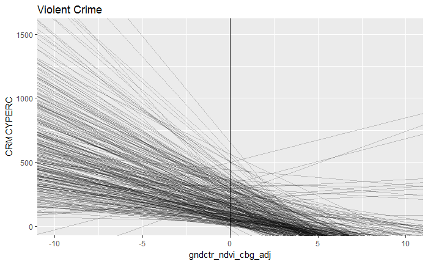

```r
estmod3b <- coef(mod_3b)$city_st
ggplot(df, aes(gndctr_ndvi_cbg_adj, CRMCYPERC)) + geom_point(alpha = 0) + geom_abline(data = estmod3b, aes(slope = gndctr_ndvi_cbg_adj, intercept = `(Intercept)`), alpha = .2) + xlim(-10, 10) + ggtitle("Violent Crime") + geom_vline(aes(xintercept = mean(gndctr_ndvi_cbg_adj)), data = df)
```

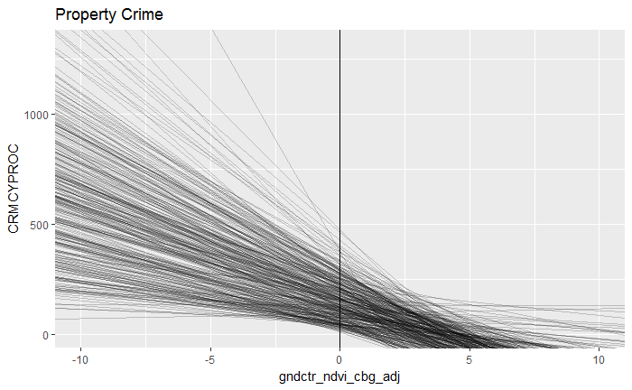

```r
estmod3c <- coef(mod_3c)$city_st
ggplot(df, aes(gndctr_ndvi_cbg_adj, CRMCYPROC)) + geom_point(alpha = 0) + geom_abline(data = estmod3c, aes(slope = gndctr_ndvi_cbg_adj, intercept = `(Intercept)`), alpha = .2) + xlim(-10, 10) + ggtitle("Property Crime") + geom_vline(aes(xintercept = mean(gndctr_ndvi_cbg_adj)), data = df)
```

With the NDVI measure grand mean centered we have 0 as the average across all block groups.(min of NDVI in cbg is -3.5500733 and max of NDVI is 3.9954796)

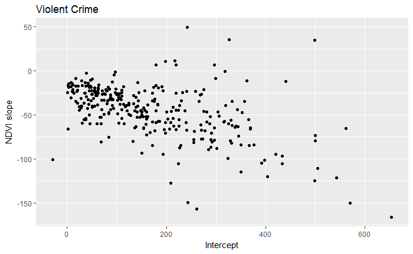

```r
estmod3b %>% mutate(city_st = row.names(.)) %>% ggplot(aes(`(Intercept)`, gndctr_ndvi_cbg_adj)) + geom_point() + labs(x = "Intercept", y = "NDVI slope", title = "Violent Crime")
```

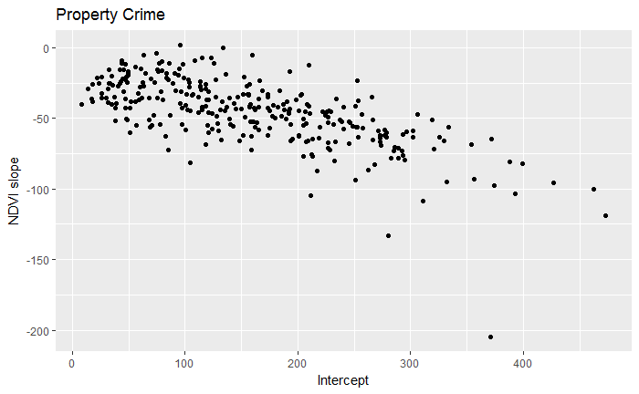

```r
estmod3c %>% mutate(city_st = row.names(.)) %>% ggplot(aes(`(Intercept)`, gndctr_ndvi_cbg_adj)) + geom_point() + labs(x = "Intercept", y = "NDVI slope", title = "Property Crime")
```